# Notebook 02 (Full Data)

## Project Objective

- This notebook presents a comprehensive end-to-end modeling pipeline for predicting default risk using the entire Home Credit dataset (not a sample). The goal is to identify clients who are likely to experience payment difficulties, based on extensive historical and application data.
- We use CatBoost, a gradient boosting model particularly well-suited for handling categorical features natively, and apply Optuna to tune hyperparameters for maximum performance. This version of the notebook represents the final cleaned, tuned, and fully cross-validated model, ready for interpretation and, with further adjustments, deployment.

## Key Features

- **Data Source**: [Kaggle - Home Credit Default Risk](https://www.kaggle.com/competitions/home-credit-default-risk/data)
- **Data Used**: All relevant relational tables merged and aggregated appropriately (`bureau`, `previous_application`, `installments_payments`, etc.)
- **Target**: `TARGET` (1 = client experienced payment difficulties, 0 = otherwise)
- **Model**: [CatBoostClassifier](https://catboost.ai)
- **Tuning**: [Optuna](https://optuna.org/) hyperparameter optimization with stratified K-fold cross-validation
- **Evaluation Metrics**: AUC, Recall, Precision, F1-score, Confusion Matrix, and SHAP interpretability

## Why CatBoost?

- Handles categorical features directly without one-hot encoding
- Efficient with large datasets
- Excellent performance on tabular, structured data

## Notebook Outline

1. Data loading and merging
2. Relational merging workflow
3. Sanity Checks and Preprocessing
4. CatBoost Modeling
5. Feature Engineering and SHAP Analysis
6. Final Model Validation and SHAP Summary
7. Conclusion

```python
# General Purpose
import os
import numpy as np
import pandas as pd

# Modeling
from catboost import CatBoostClassifier, Pool
from sklearn.model_selection import StratifiedKFold, train_test_split
from scipy.stats.mstats import winsorize

# Metrics
from sklearn.metrics import (
    classification_report,
    confusion_matrix,
    f1_score,
    precision_score,
    recall_score,
    roc_auc_score
)

# Optimization
# Hyperparameter Tuning
import optuna

optuna.logging.set_verbosity(optuna.logging.WARNING)
optuna.logging.disable_default_handler()
from optuna.pruners import SuccessiveHalvingPruner

# Visualization
import matplotlib.pyplot as plt
import seaborn as sns

import shap

# Readability
import warnings
warnings.filterwarnings("ignore")
```

# Section 1: Data loading and merging

- This section loads and integrates all the key relational tables from the Home Credit dataset into the main application data (`application_train`).
- The goal is to create a fully-featured training and testing set, preserving as much signal as possible while handling multi-table relationships properly.

### 1.1 Raw File Import

- We load the `application_train.csv` file.
- All auxiliary tables (`bureau`, `bureau_balance`, `previous_application`, `POS_CASH_balance`, `installments_payments`, and `credit_card_balance`) are read in full.
- A utility function `inspect()` is used to review basic metadata and sanity-check the tables.

```python
# Load full train and test datasets
application_train = pd.read_csv("../data/application_train.csv")

print(f"Train shape: {application_train.shape}")

# Preview
application_train.head()
```

```
Train shape: (307511, 122)
```

|  | SK_ID_CURR | TARGET | NAME_CONTRACT_TYPE | CODE_GENDER | FLAG_OWN_CAR | FLAG_OWN_REALTY | CNT_CHILDREN | AMT_INCOME_TOTAL | AMT_CREDIT | AMT_ANNUITY | ... | FLAG_DOCUMENT_18 | FLAG_DOCUMENT_19 | FLAG_DOCUMENT_20 | FLAG_DOCUMENT_21 | AMT_REQ_CREDIT_BUREAU_HOUR | AMT_REQ_CREDIT_BUREAU_DAY | AMT_REQ_CREDIT_BUREAU_WEEK | AMT_REQ_CREDIT_BUREAU_MON | AMT_REQ_CREDIT_BUREAU_QRT | AMT_REQ_CREDIT_BUREAU_YEAR |
| --- | --- | --- | --- | --- | --- | --- | --- | --- | --- | --- | --- | --- | --- | --- | --- | --- | --- | --- | --- | --- | --- |
| 0 | 100002 | 1 | Cash loans | M | N | Y | 0 | 202500.0 | 406597.5 | 24700.5 | ... | 0 | 0 | 0 | 0 | 0.0 | 0.0 | 0.0 | 0.0 | 0.0 | 1.0 |
| 1 | 100003 | 0 | Cash loans | F | N | N | 0 | 270000.0 | 1293502.5 | 35698.5 | ... | 0 | 0 | 0 | 0 | 0.0 | 0.0 | 0.0 | 0.0 | 0.0 | 0.0 |
| 2 | 100004 | 0 | Revolving loans | M | Y | Y | 0 | 67500.0 | 135000.0 | 6750.0 | ... | 0 | 0 | 0 | 0 | 0.0 | 0.0 | 0.0 | 0.0 | 0.0 | 0.0 |
| 3 | 100006 | 0 | Cash loans | F | N | Y | 0 | 135000.0 | 312682.5 | 29686.5 | ... | 0 | 0 | 0 | 0 | NaN | NaN | NaN | NaN | NaN | NaN |
| 4 | 100007 | 0 | Cash loans | M | N | Y | 0 | 121500.0 | 513000.0 | 21865.5 | ... | 0 | 0 | 0 | 0 | 0.0 | 0.0 | 0.0 | 0.0 | 0.0 | 0.0 |

5 rows × 122 columns

```python
def inspect(df, name="DataFrame"):
    print(f"\n{name} shape: {df.shape}")
    print("\nColumns:")
    print(df.columns.tolist())
    print("\nInfo:")
    print(df.info())
    print("\nPreview:")
    display(df.head())

# Inspect application_train
inspect(application_train, "Application Train")
```

```
Application Train shape: (307511, 122)

Columns:
['SK_ID_CURR', 'TARGET', 'NAME_CONTRACT_TYPE', 'CODE_GENDER', 'FLAG_OWN_CAR', 'FLAG_OWN_REALTY', 'CNT_CHILDREN', 'AMT_INCOME_TOTAL', 'AMT_CREDIT', 'AMT_ANNUITY', 'AMT_GOODS_PRICE', 'NAME_TYPE_SUITE', 'NAME_INCOME_TYPE', 'NAME_EDUCATION_TYPE', 'NAME_FAMILY_STATUS', 'NAME_HOUSING_TYPE', 'REGION_POPULA…

Info:
<class 'pandas.core.frame.DataFrame'>
RangeIndex: 307511 entries, 0 to 307510
Columns: 122 entries, SK_ID_CURR to AMT_REQ_CREDIT_BUREAU_YEAR
dtypes: float64(65), int64(41), object(16)
memory usage: 286.2+ MB
None

Preview:
```

|  | SK_ID_CURR | TARGET | NAME_CONTRACT_TYPE | CODE_GENDER | FLAG_OWN_CAR | FLAG_OWN_REALTY | CNT_CHILDREN | AMT_INCOME_TOTAL | AMT_CREDIT | AMT_ANNUITY | ... | FLAG_DOCUMENT_18 | FLAG_DOCUMENT_19 | FLAG_DOCUMENT_20 | FLAG_DOCUMENT_21 | AMT_REQ_CREDIT_BUREAU_HOUR | AMT_REQ_CREDIT_BUREAU_DAY | AMT_REQ_CREDIT_BUREAU_WEEK | AMT_REQ_CREDIT_BUREAU_MON | AMT_REQ_CREDIT_BUREAU_QRT | AMT_REQ_CREDIT_BUREAU_YEAR |
| --- | --- | --- | --- | --- | --- | --- | --- | --- | --- | --- | --- | --- | --- | --- | --- | --- | --- | --- | --- | --- | --- |
| 0 | 100002 | 1 | Cash loans | M | N | Y | 0 | 202500.0 | 406597.5 | 24700.5 | ... | 0 | 0 | 0 | 0 | 0.0 | 0.0 | 0.0 | 0.0 | 0.0 | 1.0 |
| 1 | 100003 | 0 | Cash loans | F | N | N | 0 | 270000.0 | 1293502.5 | 35698.5 | ... | 0 | 0 | 0 | 0 | 0.0 | 0.0 | 0.0 | 0.0 | 0.0 | 0.0 |
| 2 | 100004 | 0 | Revolving loans | M | Y | Y | 0 | 67500.0 | 135000.0 | 6750.0 | ... | 0 | 0 | 0 | 0 | 0.0 | 0.0 | 0.0 | 0.0 | 0.0 | 0.0 |
| 3 | 100006 | 0 | Cash loans | F | N | Y | 0 | 135000.0 | 312682.5 | 29686.5 | ... | 0 | 0 | 0 | 0 | NaN | NaN | NaN | NaN | NaN | NaN |
| 4 | 100007 | 0 | Cash loans | M | N | Y | 0 | 121500.0 | 513000.0 | 21865.5 | ... | 0 | 0 | 0 | 0 | 0.0 | 0.0 | 0.0 | 0.0 | 0.0 | 0.0 |

5 rows × 122 columns

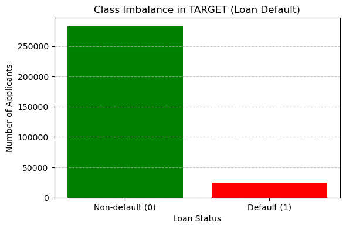

```python
# Count target classes
target_counts = application_train['TARGET'].value_counts().sort_index()

# Plot bar chart
plt.figure(figsize=(6, 4))
plt.bar(target_counts.index, target_counts.values, color=['green', 'red'])
plt.xticks([0, 1], ['Non-default (0)', 'Default (1)'])
plt.xlabel('Loan Status')
plt.ylabel('Number of Applicants')
plt.title('Class Imbalance in TARGET (Loan Default)')
plt.grid(axis='y', linestyle='--', alpha=0.7)
plt.tight_layout()
plt.show()
```

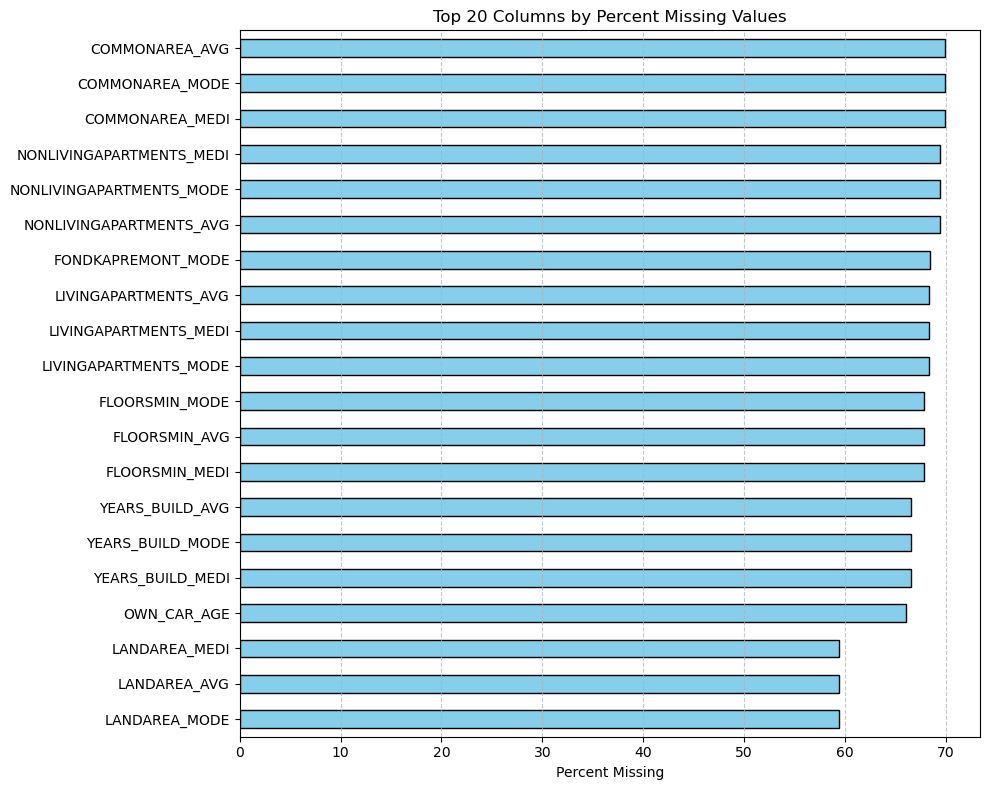

```python
# Calculate missing value percentages
missing_percent = application_train.isnull().mean().sort_values(ascending=False) * 100

# Select top 20 columns
top20_missing = missing_percent.head(20)

# Plot horizontal bar chart
plt.figure(figsize=(10, 8))
top20_missing[::-1].plot(kind='barh', color='skyblue', edgecolor='black')

# Customize plot
plt.xlabel('Percent Missing')
plt.title('Top 20 Columns by Percent Missing Values')
plt.grid(axis='x', linestyle='--', alpha=0.7)
plt.tight_layout()
plt.show()
```

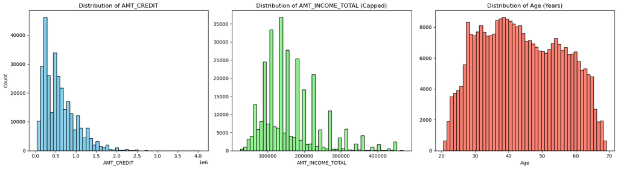

```python
# Cap AMT_INCOME_TOTAL at 99th percentile to reduce skew
income_cap = application_train["AMT_INCOME_TOTAL"].quantile(0.99)
filtered_income = application_train[application_train["AMT_INCOME_TOTAL"] < income_cap]

# Create subplot
plt.figure(figsize=(18, 5))

# AMT_CREDIT
plt.subplot(1, 3, 1)
plt.hist(application_train["AMT_CREDIT"].dropna(), bins=50, color="skyblue", edgecolor="black")
plt.title("Distribution of AMT_CREDIT")
plt.xlabel("AMT_CREDIT")
plt.ylabel("Count")

# AMT_INCOME_TOTAL (capped)
plt.subplot(1, 3, 2)
plt.hist(filtered_income["AMT_INCOME_TOTAL"], bins=50, color="lightgreen", edgecolor="black")
plt.title("Distribution of AMT_INCOME_TOTAL (Capped)")
plt.xlabel("AMT_INCOME_TOTAL")

# DAYS_BIRTH (converted to age in years)
plt.subplot(1, 3, 3)
plt.hist((-application_train["DAYS_BIRTH"] / 365).dropna(), bins=50, color="salmon", edgecolor="black")
plt.title("Distribution of Age (Years)")
plt.xlabel("Age")
plt.tight_layout()
plt.show()
```

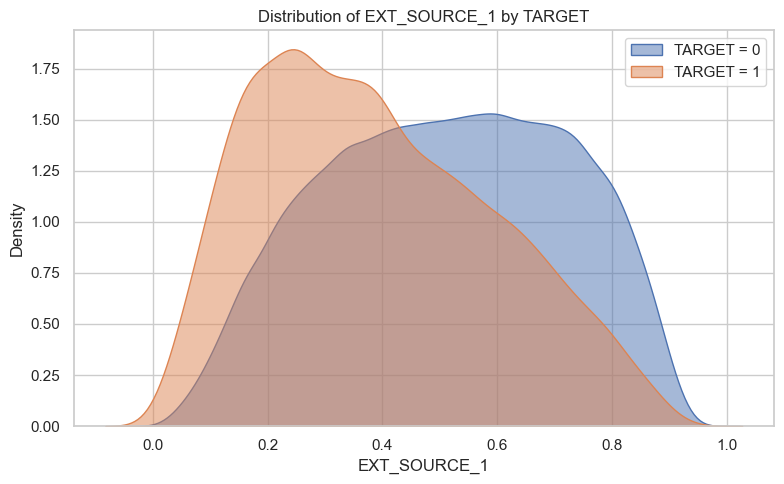

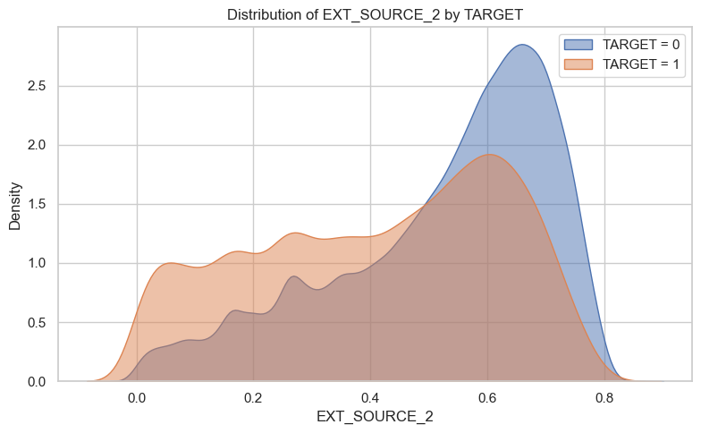

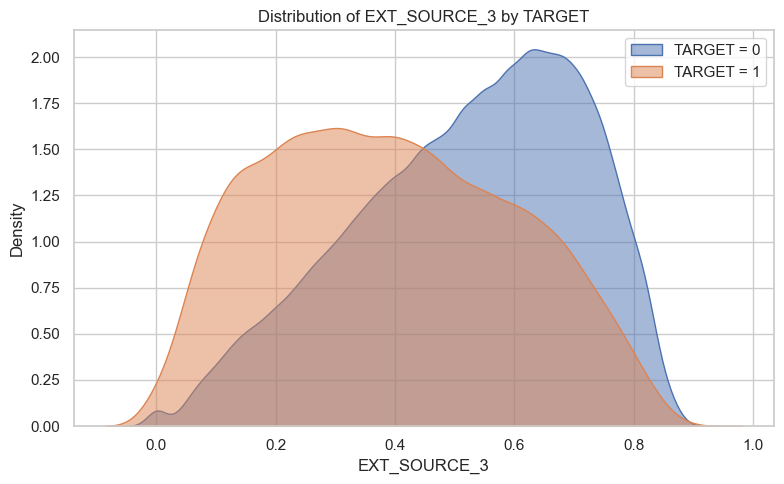

```python
# Set seaborn style
sns.set(style="whitegrid")

# Plot KDEs for EXT_SOURCE_1, EXT_SOURCE_2, EXT_SOURCE_3
for col in ["EXT_SOURCE_1", "EXT_SOURCE_2", "EXT_SOURCE_3"]:
    plt.figure(figsize=(8, 5))

    for t in [0, 1]:
        sns.kdeplot(
            data=application_train[application_train["TARGET"] == t],
            x=col,
            fill=True,
            label=f"TARGET = {t}",
            common_norm=False,
            alpha=0.5
        )

    plt.title(f"Distribution of {col} by TARGET")
    plt.xlabel(col)
    plt.legend()
    plt.tight_layout()
    plt.show()
```

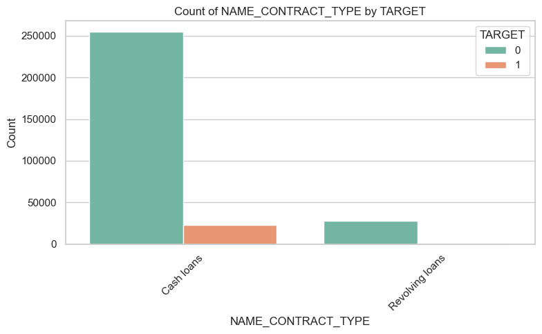

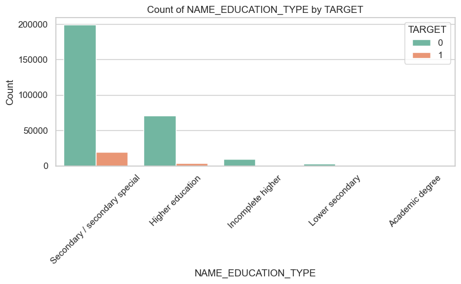

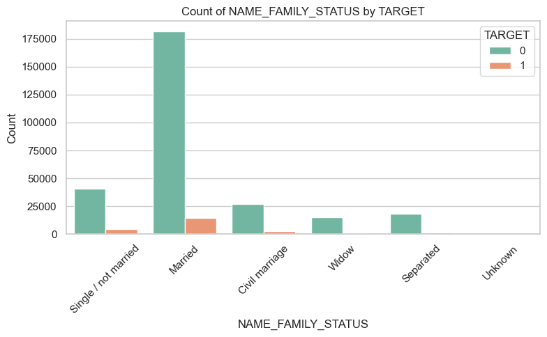

```python
# Define categorical features of interest
cat_features = ['NAME_CONTRACT_TYPE', 'NAME_EDUCATION_TYPE', 'NAME_FAMILY_STATUS']

# Plot count plots
for feature in cat_features:
    plt.figure(figsize=(8, 5))
    sns.countplot(
        data=application_train,
        x=feature,
        hue='TARGET',
        palette='Set2'
    )
    plt.title(f'Count of {feature} by TARGET')
    plt.xlabel(feature)
    plt.ylabel('Count')
    plt.xticks(rotation=45)
    plt.tight_layout()
    plt.show()
```

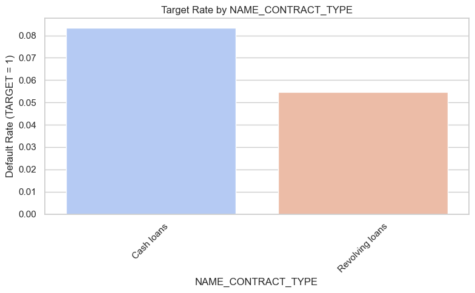

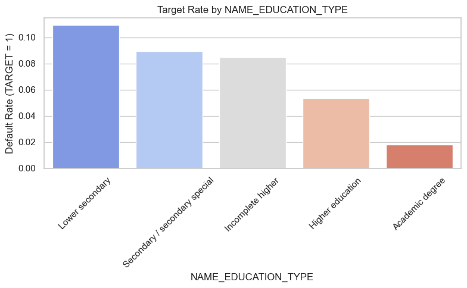

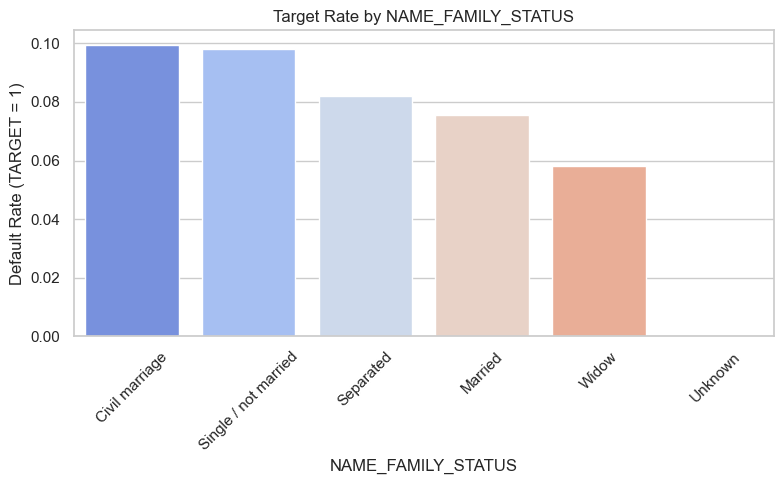

```python
for feature in cat_features:
    # Compute target mean per category
    target_rate = application_train.groupby(feature)['TARGET'].mean().sort_values(ascending=False).reset_index()

    plt.figure(figsize=(8, 5))
    sns.barplot(
        data=target_rate,
        x=feature,
        y='TARGET',
        palette='coolwarm'
    )
    plt.title(f'Target Rate by {feature}')
    plt.ylabel('Default Rate (TARGET = 1)')
    plt.xlabel(feature)
    plt.xticks(rotation=45)
    plt.tight_layout()
    plt.show()
```

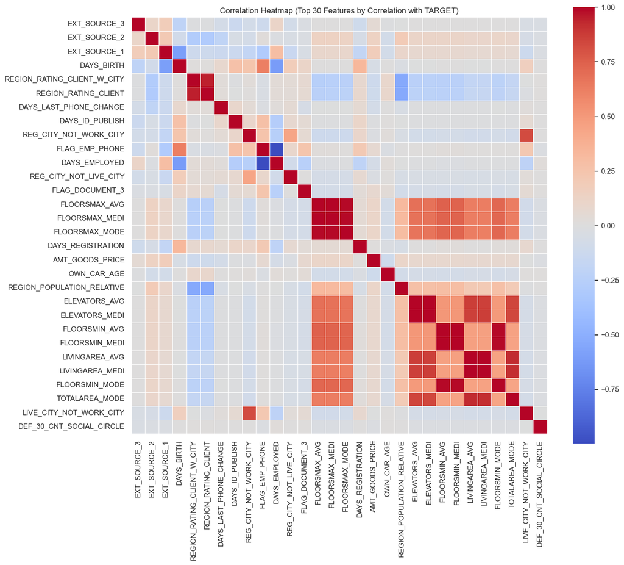

```python
# Compute correlation matrix
corr_matrix = application_train.corr(numeric_only=True)

# Get absolute correlations with TARGET and sort
target_corr = corr_matrix['TARGET'].abs().sort_values(ascending=False)

# Get names of top 30 most correlated features (excluding TARGET itself)
top_features = target_corr.drop('TARGET').head(30).index

# Subset correlation matrix
top_corr_matrix = application_train[top_features].corr()

# Plot heatmap
plt.figure(figsize=(14, 12))
sns.heatmap(top_corr_matrix, cmap='coolwarm', annot=False, fmt='.2f', square=True, linewidths=0.5)
plt.title("Correlation Heatmap (Top 30 Features by Correlation with TARGET)")
plt.tight_layout()
plt.show()
```

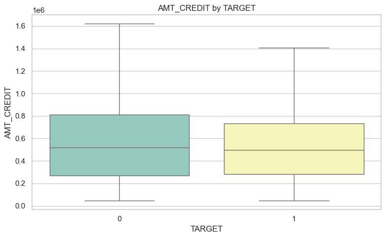

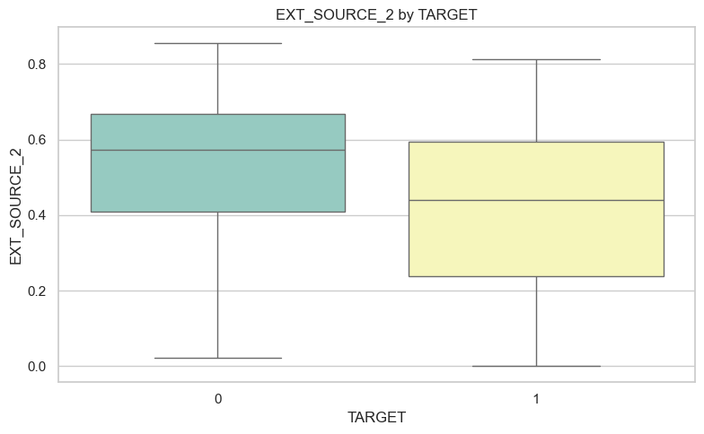

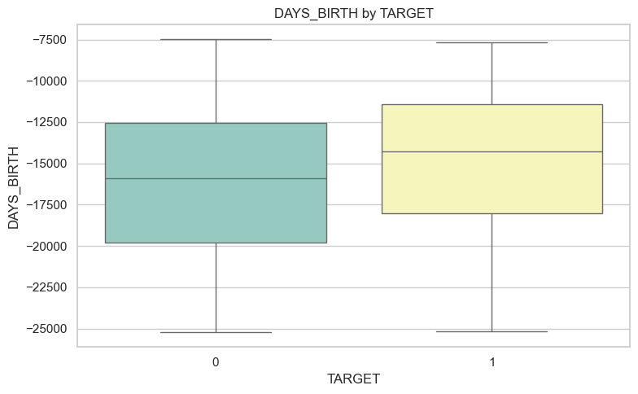

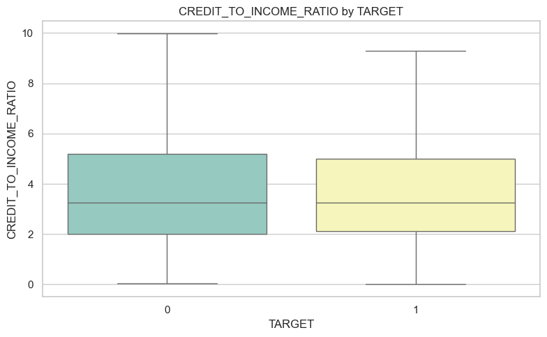

```python
application_train['CREDIT_TO_INCOME_RATIO'] = application_train['AMT_CREDIT'] / application_train['AMT_INCOME_TOTAL']

continuous_vars = ['AMT_CREDIT', 'EXT_SOURCE_2', 'DAYS_BIRTH', 'CREDIT_TO_INCOME_RATIO']

for var in continuous_vars:
    plt.figure(figsize=(8, 5))
    sns.boxplot(data=application_train, x='TARGET', y=var, palette='Set3', showfliers=False)
    plt.title(f'{var} by TARGET')
    plt.tight_layout()
    plt.show()
```

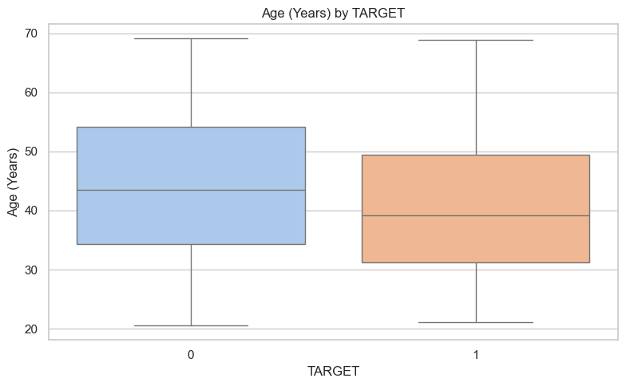

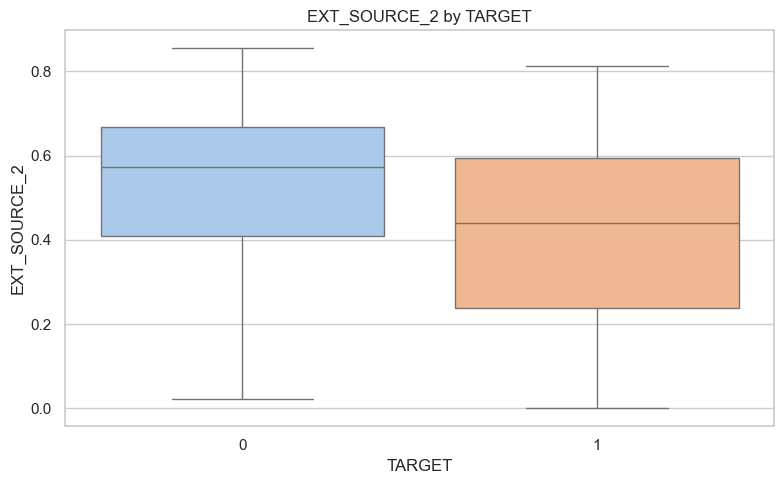

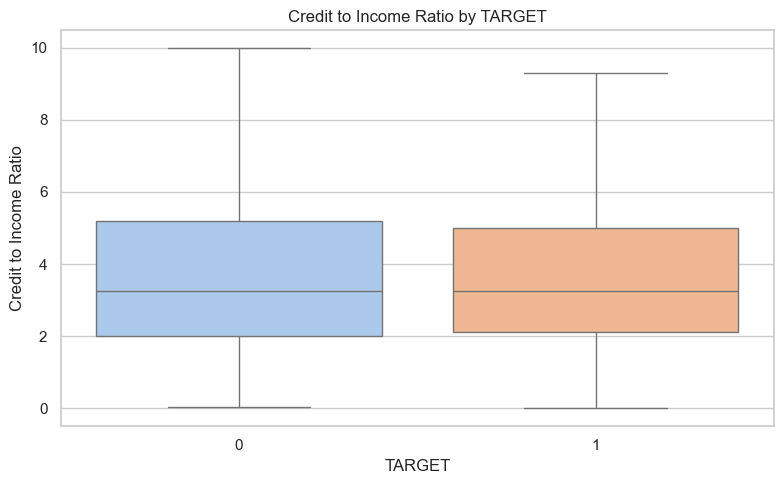

```python
# Convert DAYS_BIRTH to age in years
application_train['AGE'] = -application_train['DAYS_BIRTH'] / 365

# Variables to plot
box_vars = ['AGE', 'EXT_SOURCE_2', 'CREDIT_TO_INCOME_RATIO']
titles = ['Age (Years)', 'EXT_SOURCE_2', 'Credit to Income Ratio']

# Boxplots
for var, title in zip(box_vars, titles):
    plt.figure(figsize=(8, 5))
    sns.boxplot(data=application_train, x='TARGET', y=var, palette='pastel', showfliers=False)
    plt.title(f'{title} by TARGET')
    plt.ylabel(title)
    plt.xlabel('TARGET')
    plt.tight_layout()
    plt.show()
```

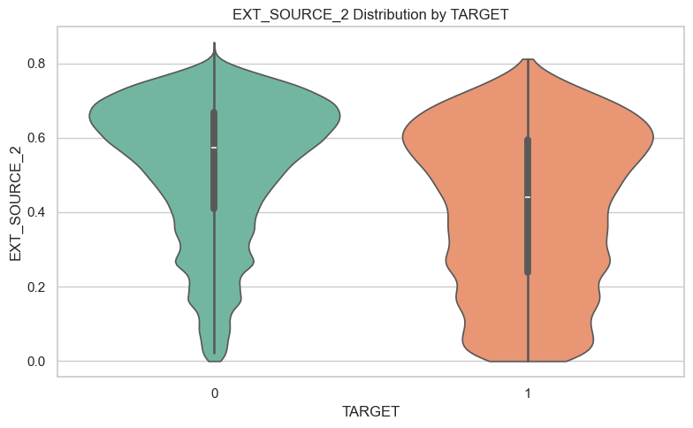

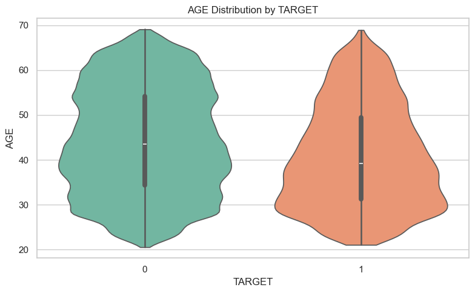

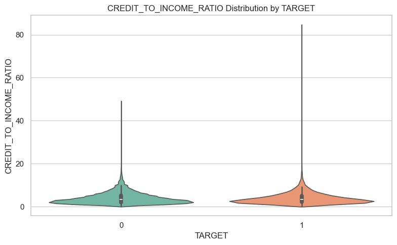

```python
shap_features = ['EXT_SOURCE_2', 'AGE', 'CREDIT_TO_INCOME_RATIO']

for var in shap_features:
    plt.figure(figsize=(8, 5))
    sns.violinplot(data=application_train, x='TARGET', y=var, palette='Set2', cut=0)
    plt.title(f'{var} Distribution by TARGET')
    plt.tight_layout()
    plt.show()
```

# Section 2: Relational merging workflow

Each related table is cleaned, aggregated, and merged into the main train/test DataFrames based on `SK_ID_CURR`. The logic below is modular so each aggregation is scoped and self-contained.

#### `bureau_balance`

- One-hot encodes the `STATUS` column.
- Aggregates monthly loan statuses by `SK_ID_BUREAU` using mean values.
- Merges into the `bureau` table.

#### `bureau`

- Aggregates numerical features by `SK_ID_CURR`.
- Merges bureau-level stats into both train and test sets.

#### `previous_application`

- Aggregates numeric stats by `SK_ID_CURR`.
- Merges into train/test.

#### `POS_CASH_balance`

- Aggregates installment and DPD-related fields by `SK_ID_PREV`.
- Then, groups again by `SK_ID_CURR` to derive one-row-per-loan features.
- Merges into train/test.

#### `installments_payments`

- Creates 3 engineered features:
  - `PAYMENT_DIFF_DAYS`, `PAYMENT_RATIO`, `PAYMENT_DIFF_AMT`.
- Aggregates payment behavior by `SK_ID_PREV`, then again by `SK_ID_CURR`.
- Merges into train/test.

#### `credit_card_balance`

- Aggregates all credit card usage stats by `SK_ID_PREV`, then `SK_ID_CURR`.
- Merges final credit card stats into train/test.

```python
# Load full bureau table
bureau = pd.read_csv("../data/bureau.csv")
inspect(bureau, "Bureau")
```

```python
# Load full bureau_balance table
bureau_bal = pd.read_csv("../data/bureau_balance.csv")
inspect(bureau_bal, "Bureau_Balance")
```

```python
# Load full previous_application table
prev_app = pd.read_csv("../data/previous_application.csv")
inspect(prev_app, "Previous Application")
```

```python
# Load full POS_CASH_balance table
pos_cash = pd.read_csv("../data/POS_CASH_balance.csv")
inspect(pos_cash, "POS_CASH Balance")
```

```python
# Load full installments_payments table
installments = pd.read_csv("../data/installments_payments.csv")
inspect(installments, "Installments Payments")
```

```python
# Load full credit_card_balance table
cc_bal = pd.read_csv("../data/credit_card_balance.csv")
inspect(cc_bal, "Credit Card Balance")
```

```python
# One-hot encode STATUS in full bureau_balance
bureau_bal_encoded = pd.get_dummies(bureau_bal, columns=["STATUS"])

# Aggregate per SK_ID_BUREAU
bureau_bal_agg = bureau_bal_encoded.groupby("SK_ID_BUREAU").agg("mean")

# Rename columns with BB_ prefix
bureau_bal_agg.columns = [f"BB_{col}" for col in bureau_bal_agg.columns]
bureau_bal_agg.reset_index(inplace=True)
```

```python
# Merge bureau with bureau_balance aggregations
bureau_merged = bureau.merge(bureau_bal_agg, on="SK_ID_BUREAU", how="left")

# No encoding — keep raw categorical columns for CatBoost
# CREDIT_ACTIVE and CREDIT_TYPE remain as-is
```

```python
bureau_numeric = bureau_merged.select_dtypes(include=['number', 'bool'])

bureau_agg = bureau_numeric.groupby("SK_ID_CURR").agg(["mean", "max", "min", "std", "sum"])

bureau_agg.columns = ["BUREAU_" + "_".join(col).upper() for col in bureau_agg.columns]
```

```python
# Merge bureau features into train and test
application_train = application_train.merge(bureau_agg, on="SK_ID_CURR", how="left")
```

```python
# Use full previous_application directly (already loaded as prev_app)
prev = prev_app  # aliasing for clarity in aggregation step
```

```python
# Aggregate numeric features from previous_application
prev_numeric = prev.select_dtypes(include=["number", "bool"])

prev_agg = prev_numeric.groupby("SK_ID_CURR").agg(["mean", "max", "min", "std", "sum"])
```

```python
# Add PREVAPP_ prefix to identify columns later
prev_agg.columns = ["PREVAPP_" + "_".join(col).upper() for col in prev_agg.columns]
prev_agg.reset_index(inplace=True)
```

```python
# Merge previous_application features into train and test
application_train = application_train.merge(prev_agg, on="SK_ID_CURR", how="left")
```

```python
# Use already-loaded full POS_CASH_balance data
pos = pos_cash
```

```python
pos_agg_by_loan = pos.groupby("SK_ID_PREV").agg({
    "MONTHS_BALANCE": ["min", "max", "count"],
    "SK_DPD": ["mean", "max"],
    "SK_DPD_DEF": ["mean", "max"],
    "CNT_INSTALMENT": ["mean", "max", "min"],
    "CNT_INSTALMENT_FUTURE": ["mean", "max", "min"]
})


pos_agg_by_loan.columns = ["POS_" + "_".join(col).upper() for col in pos_agg_by_loan.columns]
pos_agg_by_loan.reset_index(inplace=True)
```

```python
pos_with_curr = pos_agg_by_loan.merge(prev[["SK_ID_PREV", "SK_ID_CURR"]], on="SK_ID_PREV", how="left")
```

```python
pos_final = pos_with_curr.drop(columns=["SK_ID_PREV"]).groupby("SK_ID_CURR").agg("mean")
pos_final.reset_index(inplace=True)
```

```python
# Merge POS features into train and test
application_train = application_train.merge(pos_final, on="SK_ID_CURR", how="left")
```

```python
installments["PAYMENT_DIFF_DAYS"] = installments["DAYS_ENTRY_PAYMENT"] - installments["DAYS_INSTALMENT"]
installments["PAYMENT_RATIO"] = installments["AMT_PAYMENT"] / installments["AMT_INSTALMENT"]
installments["PAYMENT_DIFF_AMT"] = installments["AMT_PAYMENT"] - installments["AMT_INSTALMENT"]
```

```python
inst_agg_by_loan = installments.groupby("SK_ID_PREV").agg({
    "PAYMENT_DIFF_DAYS": ["mean", "min", "max"],
    "PAYMENT_RATIO": ["mean", "min", "max"],
    "PAYMENT_DIFF_AMT": ["mean", "min", "max"],
    "AMT_PAYMENT": ["sum"],
    "AMT_INSTALMENT": ["sum"],
    "DAYS_ENTRY_PAYMENT": ["max"],
    "DAYS_INSTALMENT": ["max"]
})
```

```python
inst_agg_by_loan.columns = ["INSTALL_" + "_".join(col).upper() for col in inst_agg_by_loan.columns]
inst_agg_by_loan.reset_index(inplace=True)
```

```python
inst_with_curr = inst_agg_by_loan.merge(prev[["SK_ID_PREV", "SK_ID_CURR"]], on="SK_ID_PREV", how="left")
```

```python
inst_final = inst_with_curr.drop(columns=["SK_ID_PREV"]).groupby("SK_ID_CURR").agg("mean")
inst_final.reset_index(inplace=True)
```

```python
# Final merge: Installment features into train and test
application_train = application_train.merge(inst_final, on="SK_ID_CURR", how="left")
```

```python
cc_agg_by_card = cc_bal.groupby("SK_ID_PREV").agg({
    "MONTHS_BALANCE": ["min", "max", "count"],
    "AMT_BALANCE": ["mean", "max"],
    "AMT_CREDIT_LIMIT_ACTUAL": ["mean"],
    "AMT_DRAWINGS_ATM_CURRENT": ["mean", "sum"],
    "AMT_DRAWINGS_CURRENT": ["mean", "sum"],
    "AMT_PAYMENT_CURRENT": ["mean", "sum"],
    "AMT_TOTAL_RECEIVABLE": ["mean", "max"],
    "SK_DPD": ["mean", "max"],
    "SK_DPD_DEF": ["mean", "max"],
    "CNT_DRAWINGS_CURRENT": ["mean", "sum"],
    "CNT_INSTALMENT_MATURE_CUM": ["max"],
    "CNT_DRAWINGS_OTHER_CURRENT": ["mean"]
})
```

```python
cc_agg_by_card.columns = ["CC_" + "_".join(col).upper() for col in cc_agg_by_card.columns]
cc_agg_by_card.reset_index(inplace=True)
```

```python
# Use already-loaded full previous_application table
cc_with_curr = cc_agg_by_card.merge(prev_app[["SK_ID_PREV", "SK_ID_CURR"]], on="SK_ID_PREV", how="left")
```

```python
cc_final = cc_with_curr.drop(columns=["SK_ID_PREV"]).groupby("SK_ID_CURR").agg("mean")
cc_final.reset_index(inplace=True)
```

```python
# Final merge: Credit card features into train and test
application_train = application_train.merge(cc_final, on="SK_ID_CURR", how="left")
```

# Section 3: Sanity Checks and Preprocessing

- Summary table reports:
  - Data type
  - Missing values (count and ratio)
  - Unique values per column
- Drops columns with excessive missingness (from `previous_application` interest rate columns).
- Winsorizes all numeric columns (except `TARGET`) to cap extreme outliers at the 1st and 99th percentiles.

```python
# Summary of nulls and cardinality — skip SK_ID_CURR/TARGET only
df = application_train.copy()
df_summary = df.drop(columns=["SK_ID_CURR", "TARGET"])

null_summary = pd.DataFrame({
    'dtype': df_summary.dtypes,
    'null_count': df_summary.isnull().sum(),
    'null_ratio': df_summary.isnull().mean(),
    'n_unique': df_summary.nunique()
}).sort_values(by="null_ratio", ascending=False)

null_summary.head(30)
```

|  | dtype | null_count | null_ratio | n_unique |
| --- | --- | --- | --- | --- |
| PREVAPP_RATE_INTEREST_PRIVILEGED_STD | float64 | 307337 | 0.999434 | 27 |
| PREVAPP_RATE_INTEREST_PRIMARY_STD | float64 | 307337 | 0.999434 | 54 |
| PREVAPP_RATE_INTEREST_PRIVILEGED_MEAN | float64 | 302902 | 0.985012 | 45 |
| PREVAPP_RATE_INTEREST_PRIMARY_MAX | float64 | 302902 | 0.985012 | 134 |
| PREVAPP_RATE_INTEREST_PRIMARY_MEAN | float64 | 302902 | 0.985012 | 184 |
| PREVAPP_RATE_INTEREST_PRIVILEGED_MIN | float64 | 302902 | 0.985012 | 23 |
| PREVAPP_RATE_INTEREST_PRIVILEGED_MAX | float64 | 302902 | 0.985012 | 23 |
| PREVAPP_RATE_INTEREST_PRIMARY_MIN | float64 | 302902 | 0.985012 | 133 |
| CC_AMT_PAYMENT_CURRENT_MEAN | float64 | 254669 | 0.828162 | 48603 |
| CC_AMT_DRAWINGS_ATM_CURRENT_MEAN | float64 | 254581 | 0.827876 | 20059 |
| CC_CNT_DRAWINGS_OTHER_CURRENT_MEAN | float64 | 254581 | 0.827876 | 423 |
| BUREAU_AMT_ANNUITY_STD | float64 | 244952 | 0.796563 | 36556 |
| CC_SK_DPD_DEF_MEAN | float64 | 229577 | 0.746565 | 1386 |
| CC_SK_DPD_DEF_MAX | float64 | 229577 | 0.746565 | 42 |
| CC_CNT_INSTALMENT_MATURE_CUM_MAX | float64 | 229577 | 0.746565 | 133 |
| CC_CNT_DRAWINGS_CURRENT_MEAN | float64 | 229577 | 0.746565 | 6456 |
| CC_CNT_DRAWINGS_CURRENT_SUM | float64 | 229577 | 0.746565 | 605 |
| CC_MONTHS_BALANCE_COUNT | float64 | 229577 | 0.746565 | 145 |
| CC_MONTHS_BALANCE_MAX | float64 | 229577 | 0.746565 | 5 |
| CC_AMT_BALANCE_MAX | float64 | 229577 | 0.746565 | 49151 |
| CC_AMT_DRAWINGS_ATM_CURRENT_SUM | float64 | 229577 | 0.746565 | 4630 |
| CC_AMT_PAYMENT_CURRENT_SUM | float64 | 229577 | 0.746565 | 46155 |
| CC_AMT_CREDIT_LIMIT_ACTUAL_MEAN | float64 | 229577 | 0.746565 | 10699 |
| CC_AMT_TOTAL_RECEIVABLE_MEAN | float64 | 229577 | 0.746565 | 51340 |
| CC_SK_DPD_MEAN | float64 | 229577 | 0.746565 | 2969 |
| CC_SK_DPD_MAX | float64 | 229577 | 0.746565 | 386 |
| CC_AMT_DRAWINGS_CURRENT_SUM | float64 | 229577 | 0.746565 | 37332 |
| CC_AMT_DRAWINGS_CURRENT_MEAN | float64 | 229577 | 0.746565 | 44708 |
| CC_AMT_BALANCE_MEAN | float64 | 229577 | 0.746565 | 51559 |
| CC_AMT_TOTAL_RECEIVABLE_MAX | float64 | 229577 | 0.746565 | 48888 |

```python
# Drop columns with too many nulls from training data
drop_cols = [
    'PREVAPP_RATE_INTEREST_PRIVILEGED_STD',
    'PREVAPP_RATE_INTEREST_PRIMARY_STD',
    'PREVAPP_RATE_INTEREST_PRIMARY_MEAN',
    'PREVAPP_RATE_INTEREST_PRIVILEGED_MEAN',
    'PREVAPP_RATE_INTEREST_PRIVILEGED_MAX',
    'PREVAPP_RATE_INTEREST_PRIVILEGED_MIN',
    'PREVAPP_RATE_INTEREST_PRIMARY_MIN',
    'PREVAPP_RATE_INTEREST_PRIMARY_MAX'
]

df.drop(columns=drop_cols, inplace=True)
```

```python
# Winsorize all numeric feature columns (excluding 'TARGET')
numeric_cols = df.select_dtypes(include=["number"]).columns.drop("TARGET")

for col in numeric_cols:
    df[col] = winsorize(df[col], limits=[0.01, 0.01]).data

print(df['TARGET'].value_counts())
```

```
TARGET
0    282686
1     24825
Name: count, dtype: int64
```

## 3.1 Train/Validation/Test Split

- Splits the full dataset into:
  - Train (60%)
  - Validation (20%)
  - Test (20%)
- Uses `StratifiedShuffleSplit` logic via `train_test_split()` to maintain `TARGET` balance across splits.

```python
X = df.drop(columns=["SK_ID_CURR", "TARGET"])
y = df["TARGET"]
```

```python
# Identify categorical column names for CatBoost
cat_features = X.select_dtypes(include=["object"]).columns.tolist()
X[cat_features] = X[cat_features].fillna("Missing")
```

```python
# Split the raw X and y — no scaling, no cleaning
X_train_val, X_test, y_train_val, y_test = train_test_split(
    X, y, test_size=0.2, stratify=y, random_state=42
)

X_train, X_val, y_train, y_val = train_test_split(
    X_train_val, y_train_val, test_size=0.25, stratify=y_train_val, random_state=42
)
```

## 3.2 Notes / Inconsistencies Checked

- Each auxiliary table is successfully joined using consistent keys (`SK_ID_CURR` or `SK_ID_PREV`).
- All merges are left joins to prevent data loss in the main tables.
- All engineered features are renamed with clear prefixes (`BB_`, `PREVAPP_`, `POS_`, `INSTALL_`, `CC_`), avoiding column collisions.
- No observed leakage — aggregations are scoped to past behavior only (i.e., not using future payment dates or default outcomes).

# Section 4: CatBoost Modeling

- This section builds, tunes, and optimizes a CatBoost classification model to predict default risk using the fully engineered dataset.
- CatBoost is chosen due to its superior handling of categorical features and its efficiency on structured/tabular data.

## 4.1 Initial Run (Baseline CatBoost Model)

A baseline `CatBoostClassifier` is trained using manually set parameters.

```python
# Baseline CatBoost model
cat_model = CatBoostClassifier(
    iterations=500,
    learning_rate=0.1,
    depth=6,
    eval_metric='AUC',
    random_seed=42,
    verbose=100,
    early_stopping_rounds=50
)

# Fit model with categorical features
cat_model.fit(
    X_train, y_train,
    eval_set=(X_val, y_val),
    cat_features=cat_features,
    use_best_model=True
)

# Predict probabilities and threshold at 0.5
y_pred_proba = cat_model.predict_proba(X_val)[:, 1]
y_pred_default = (y_pred_proba > 0.5).astype(int)

# Report metrics
print("Baseline CatBoost Results (Threshold = 0.5)")
print(f"AUC: {roc_auc_score(y_val, y_pred_proba):.4f}")
print(classification_report(y_val, y_pred_default, digits=3))
print(confusion_matrix(y_val, y_pred_default))
```

```
0:  test: 0.5612338 best: 0.5612338 (0) total: 520ms    remaining: 4m 19s
100:    test: 0.7672985 best: 0.7672985 (100)   total: 30.7s    remaining: 2m 1s
200:    test: 0.7733849 best: 0.7733972 (199)   total: 1m   remaining: 1m 30s
300:    test: 0.7762936 best: 0.7762936 (300)   total: 1m 30s   remaining: 59.6s
400:    test: 0.7773160 best: 0.7773160 (400)   total: 1m 59s   remaining: 29.4s
499:    test: 0.7780844 best: 0.7780844 (499)   total: 2m 30s   remaining: 0us

bestTest = 0.7780844317
bestIteration = 499

Baseline CatBoost Results (Threshold = 0.5)
AUC: 0.7781
              precision    recall  f1-score   support

           0      0.922     0.997     0.958     56537
           1      0.520     0.040     0.074      4965

    accuracy                          0.920     61502
   macro avg      0.721     0.518     0.516     61502
weighted avg      0.890     0.920     0.887     61502

[[56354   183]
 [ 4767   198]]
```

## 4.2 Optuna Hyperparameter Tuning

```python
def objective(trial):
    params = {
        'iterations': 1000,
        'learning_rate': trial.suggest_float('learning_rate', 0.01, 0.3, log=True),
        'depth': trial.suggest_int('depth', 3, 10),
        'l2_leaf_reg': trial.suggest_float('l2_leaf_reg', 1, 10),
        'bootstrap_type': 'Bernoulli',
        'eval_metric': 'AUC',
        'random_seed': 42,
        'early_stopping_rounds': 50,
        'verbose': 0,
        'class_weights': [1, 15],  # Based on class imbalance
    }

    # Local train/val split inside objective (to avoid leak from global val)
    X_tr, X_val_, y_tr, y_val_ = train_test_split(
        X_train, y_train, test_size=0.2, stratify=y_train, random_state=42
    )

    model = CatBoostClassifier(**params)
    model.fit(
        X_tr, y_tr,
        eval_set=(X_val_, y_val_),
        cat_features=cat_features,
        use_best_model=True
    )

    preds = model.predict_proba(X_val_)[:, 1]
    return roc_auc_score(y_val_, preds)

# Run Optuna
pruner = SuccessiveHalvingPruner()
study = optuna.create_study(direction='maximize', pruner=pruner)
study.optimize(objective, n_trials=15, n_jobs=1)

# Show best result
print(f"Best AUC {study.best_value:.4f}")
print("Best Parameters")
for k, v in study.best_params.items():
    print(f"{k}: {v}")
```

```
Best AUC: 0.7795
Best Parameters:
learning_rate: 0.03759227415469158
depth: 6
l2_leaf_reg: 7.24195964417585
```

## 4.3 Threshold Tuning

- Rather than defaulting to a 0.5 threshold, we identify the optimal threshold based on F1-score maximization:
  - Refit model with best Optuna parameters on training data.
  - Generate probabilities on validation set (y_pred_prob_cb).
  - Evaluate multiple thresholds from 0.05 to 0.95.
  - Select threshold with maximum F1-score (best_threshold_cb).
  - Final predictions and classification report are generated using this threshold.

```python
# Final Evaluation using best Optuna parameters

# Refit best model on full training set
best_cb = CatBoostClassifier(
    **study.best_params,
    iterations=1000,
    random_seed=42,
    verbose=0,
    cat_features=cat_features
)

best_cb.fit(X_train, y_train, eval_set=(X_val, y_val), use_best_model=True)

# Predict probabilities
y_pred_proba_cb = best_cb.predict_proba(X_val)[:, 1]

# Threshold tuning loop
thresholds = np.arange(0.05, 0.95, 0.05)
f1_scores = [f1_score(y_val, y_pred_proba_cb > thr) for thr in thresholds]
best_threshold_cb = thresholds[np.argmax(f1_scores)]

# Apply best threshold
y_pred_final_cb = (y_pred_proba_cb > best_threshold_cb).astype(int)

# Report
print(f"Final CatBoost Evaluation (Threshold = {best_threshold_cb:.2f})")
print(f"AUC {roc_auc_score(y_val, y_pred_proba_cb):.4f}")
print(classification_report(y_val, y_pred_final_cb, digits=3))
print(confusion_matrix(y_val, y_pred_final_cb))
```

```
Final CatBoost Evaluation (Threshold = 0.15)
AUC: 0.7790
              precision    recall  f1-score   support

           0      0.948     0.886     0.916     56537
           1      0.257     0.450     0.327      4965

    accuracy                          0.851     61502
   macro avg      0.603     0.668     0.622     61502
weighted avg      0.892     0.851     0.868     61502

[[50083  6454]
 [ 2731  2234]]
```

# Section 5: Feature Engineering and SHAP Analysis

- This section finalizes the modeling process by engineering domain-relevant features and interpreting model behavior using SHAP.
- Feature engineering is done post-baseline modeling to avoid data leakage, and SHAP plots are generated for interpretability.

## 5.1 SHAP Function (for CatBoost)

This helps interpret model logic both globally (what matters most) and locally (why a specific prediction was made).

```python
# Feature analysis - SHAP function
def explain_model_with_shap(model, X, model_name="Model", pred_probs=None, class_index=1, top_n=3):
    """
    Generate SHAP summary and force plots for a tree-based model (CatBoost, XGBoost, LightGBM, Random Forest).

    Parameters:
    - model: trained tree-based model
    - X: DataFrame of features
    - model_name: Title used in plots
    - pred_probs: Predicted probabilities (for top_n force plots)
    - class_index: Only needed if SHAP returns a list (e.g., CatBoost, RandomForest)
    - top_n: Number of highest-risk examples to show in force plots
    """

    print(f"\nGenerating SHAP explanations for: {model_name}")

    # Create SHAP explainer
    explainer = shap.TreeExplainer(model)
    shap_values = explainer.shap_values(X)

    # Binary classification: choose class index
    if isinstance(shap_values, list):
        shap_values = shap_values[class_index]
        expected_value = explainer.expected_value[class_index]
    else:
        expected_value = explainer.expected_value

    # Global Feature Importance (Bar)
    print(f"\n{model_name} - Global Feature Importance")
    shap.summary_plot(shap_values, X, plot_type="bar")

    # SHAP Summary Plot (Violin)
    print(f"\n{model_name} - SHAP Summary Plot")
    shap.summary_plot(shap_values, X)

    # Local SHAP force plots for top_n high-risk cases
    if pred_probs is not None:
        top_idx = np.argsort(pred_probs)[-top_n:]
        for i in reversed(top_idx):
            print(f"\n{model_name} - SHAP Force Plot for Row {i} (Prob = {pred_probs[i]:.3f})")
            shap.force_plot(
                base_value=expected_value,
                shap_values=shap_values[i],
                features=X.iloc[i],
                matplotlib=True
            )
```

## 5.2 CatBoost (feature analysis)

```
Generating SHAP explanations for: CatBoost

CatBoost - Global Feature Importance
```

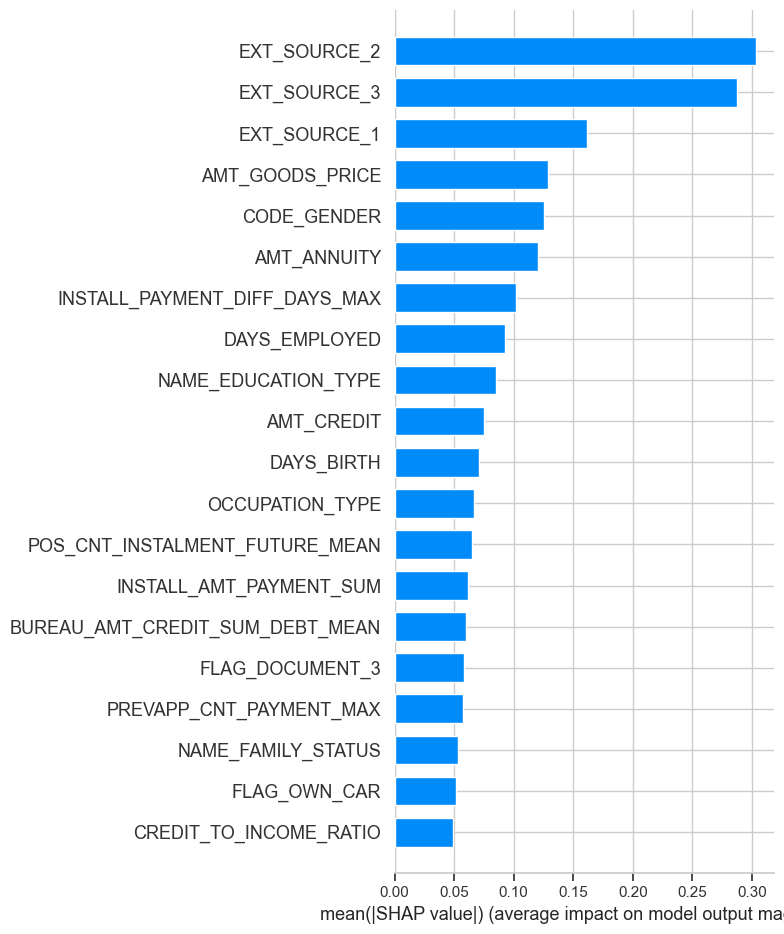

```
CatBoost - SHAP Summary Plot
```

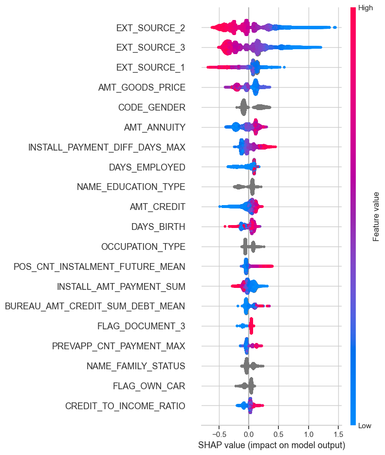

```
CatBoost - SHAP Force Plot for Row 61079 (Prob = 0.907)
```

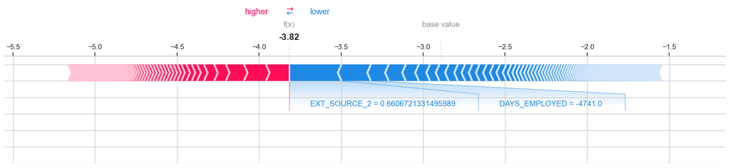

```
CatBoost - SHAP Force Plot for Row 57347 (Prob = 0.869)
```

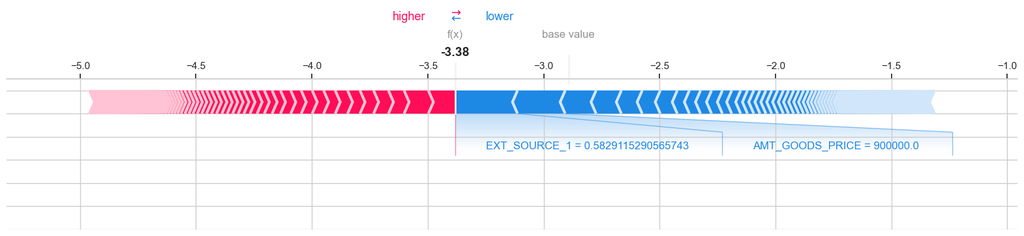

```
CatBoost - SHAP Force Plot for Row 53728 (Prob = 0.855)
```

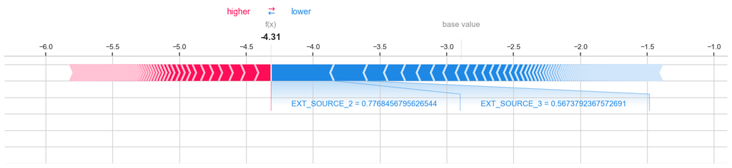

```python
explain_model_with_shap(
    model=cat_model,             # Final trained CatBoost model
    X=X_test,                    # Raw test features — no scaling (CatBoost handles raw data)
    model_name="CatBoost",
    pred_probs=y_pred_proba_cb, # Shape: (n_samples,) or [:, 1] if shape is (n_samples, 2)
    class_index=1                # Needed — CatBoost returns a list of SHAP arrays
)
```

## 5.3 Feature Engineering for CatBoost

We engineer several groups of features based on financial intuition and domain insight. The process is performed after the initial CatBoost evaluation and before running the final tuned model. - Ratio-Based Interactions `CREDIT_INCOME_RATIO`, `ANNUITY_INCOME_RATIO`, `GOODS_CREDIT_RATIO`, `EMPLOYED_BIRTH_RATIO` - Log Transforms `LOG_CREDIT`, `LOG_INCOME`, `LOG_EMPLOYED_RATIO` - Temporal Ratios `REGISTRATION_AGE_RATIO`, `ID_PUBLISH_AGE_RATIO` - Document and Contact Flags Sum of document flags and presence of phone/email indicators - Social Circle Default Ratios `DEF_30_RATIO`, `DEF_60_RATIO` (defaults relative to social observation size)

All operations are applied to a copy of the dataset (`X_catboost`) to preserve the original.

```python
# Create a working copy so original X_clean stays untouched
X_catboost = X.copy()

# Ratio-based feature interactions
X_catboost["CREDIT_INCOME_RATIO"]     = X_catboost["AMT_CREDIT"] / (X_catboost["AMT_INCOME_TOTAL"] + 1e-5)
X_catboost["ANNUITY_INCOME_RATIO"]    = X_catboost["AMT_ANNUITY"] / (X_catboost["AMT_INCOME_TOTAL"] + 1e-5)
X_catboost["GOODS_CREDIT_RATIO"]      = X_catboost["AMT_GOODS_PRICE"] / (X_catboost["AMT_CREDIT"] + 1e-5)
X_catboost["EMPLOYED_BIRTH_RATIO"]    = X_catboost["DAYS_EMPLOYED"] / (X_catboost["DAYS_BIRTH"] + 1e-5)

# Log transforms
X_catboost["LOG_CREDIT"]              = np.log1p(X_catboost["AMT_CREDIT"])
X_catboost["LOG_INCOME"]              = np.log1p(X_catboost["AMT_INCOME_TOTAL"])
X_catboost["LOG_EMPLOYED_RATIO"]      = np.log1p(abs(X_catboost["EMPLOYED_BIRTH_RATIO"]))

# Temporal ratios
X_catboost["REGISTRATION_AGE_RATIO"]  = X_catboost["DAYS_REGISTRATION"] / (X_catboost["DAYS_BIRTH"] + 1e-5)
X_catboost["ID_PUBLISH_AGE_RATIO"]    = X_catboost["DAYS_ID_PUBLISH"] / (X_catboost["DAYS_BIRTH"] + 1e-5)

# Document and contact flags
doc_flags = [col for col in X_catboost.columns if "FLAG_DOCUMENT_" in col]
X_catboost["NUM_DOCUMENTS_SUBMITTED"] = X_catboost[doc_flags].sum(axis=1)

contact_flags = ['FLAG_EMP_PHONE', 'FLAG_WORK_PHONE', 'FLAG_CONT_MOBILE', 'FLAG_PHONE', 'FLAG_EMAIL']
X_catboost["NUM_CONTACT_FLAGS"]       = X_catboost[contact_flags].sum(axis=1)

# Social circle default ratios
X_catboost["DEF_30_RATIO"]            = X_catboost["DEF_30_CNT_SOCIAL_CIRCLE"] / (X_catboost["OBS_30_CNT_SOCIAL_CIRCLE"] + 1e-5)
X_catboost["DEF_60_RATIO"]            = X_catboost["DEF_60_CNT_SOCIAL_CIRCLE"] / (X_catboost["OBS_60_CNT_SOCIAL_CIRCLE"] + 1e-5)

print(f"Feature engineering complete. New shape: {X_catboost.shape}")
```

```
Feature engineering complete. New shape: (307511, 385)
```

## 5.4 Final Train/Val/Test Split (CatBoost Features)

- A new stratified 60/20/20 split is done using the engineered features.
- This ensures final model training uses the most robust signal.
- Label balance is confirmed in each set.

```python
# Split off test set (20%)
X_trainval_catboost, X_test_catboost, y_trainval_catboost, y_test_catboost = train_test_split(
    X_catboost, y, test_size=0.2, stratify=y, random_state=42
)

# Split remaining data into train (60%) and validation (20%)
X_train_catboost, X_val_catboost, y_train_catboost, y_val_catboost = train_test_split(
    X_trainval_catboost, y_trainval_catboost, test_size=0.25, stratify=y_trainval_catboost, random_state=42
)
# 0.25 of 0.8 = 0.2 → results in 60/20/20 split

# Sanity checks
print(f"X_train_catboost shape: {X_train_catboost.shape}")
print(f"X_val_catboost   shape: {X_val_catboost.shape}")
print(f"X_test_catboost  shape: {X_test_catboost.shape}\n")

print(f"y_train_catboost class balance:\n{y_train_catboost.value_counts(normalize=True)}\n")
print(f"y_val_catboost   class balance:\n{y_val_catboost.value_counts(normalize=True)}\n")
print(f"y_test_catboost  class balance:\n{y_test_catboost.value_counts(normalize=True)}")
```

```
X_train_catboost shape: (184506, 385)
X_val_catboost   shape: (61502, 385)
X_test_catboost  shape: (61503, 385)

y_train_catboost class balance:
TARGET
0    0.919271
1    0.080729
Name: proportion, dtype: float64

y_val_catboost   class balance:
TARGET
0    0.919271
1    0.080729
Name: proportion, dtype: float64

y_test_catboost  class balance:
TARGET
0    0.919272
1    0.080728
Name: proportion, dtype: float64
```

# Section 6: Final Model Validation and SHAP Summary

- This section brings together all the optimized components—feature engineering, Optuna tuning, and threshold calibration—into a final, cross-validated evaluation loop.
- SHAP analysis is then applied at both global and local levels to understand how different feature domains contribute to model decisions.

## 6.1 Final Cross-Validated Model (Optuna-Tuned + Threshold-Tuned)

- Uses the best hyperparameters from Optuna and the optimal classification threshold based on F1-score.
- Performs Stratified K-Fold cross-validation across all engineered data:
  - Trains using `CatBoostClassifier` wrapped with `Pool` to handle categorical features natively.
  - Applies threshold to maximize F1.
  - Captures per-fold AUC, F1-score, and confusion matrix.

### Initial run (CatBoost with added features)

```python
# Identify categorical columns by name
cat_features = X_catboost.select_dtypes(include="object").columns.tolist()

# Wrap data in CatBoost Pool objects (handles categorical features safely)
train_pool = Pool(data=X_train_catboost, label=y_train_catboost, cat_features=cat_features)
val_pool   = Pool(data=X_val_catboost, label=y_val_catboost, cat_features=cat_features)

# Initialize baseline model
baseline_cb = CatBoostClassifier(
    verbose=0,
    random_state=42
)

# Train on training set, predict on validation set
baseline_cb.fit(train_pool, eval_set=val_pool)
y_pred_cb_proba = baseline_cb.predict_proba(X_val_catboost)[:, 1]

# Evaluate AUC on validation set
baseline_auc = roc_auc_score(y_val_catboost, y_pred_cb_proba)
print(f"\nInitial CatBoost AUC (Validation Set): {baseline_auc:.4f}")
```

```
Initial CatBoost AUC (Validation Set): 0.7796
```

## 6.3 Oputna (CatBoost with added features)

```python
import optuna
from catboost import Pool, CatBoostClassifier
from sklearn.metrics import roc_auc_score
from sklearn.model_selection import StratifiedKFold

# Define Optuna objective function
def objective(trial):
    params = {
        "iterations": 1000,
        "learning_rate": trial.suggest_float("learning_rate", 0.01, 0.3),
        "depth": trial.suggest_int("depth", 4, 10),
        "l2_leaf_reg": trial.suggest_float("l2_leaf_reg", 1.0, 10.0),
        "bootstrap_type": trial.suggest_categorical("bootstrap_type", ["Bayesian", "Bernoulli", "MVS"]),
        "eval_metric": "AUC",
        "random_seed": 42,
        "verbose": 0,
        "scale_pos_weight": y_train_catboost.value_counts()[0] / y_train_catboost.value_counts()[1]  # auto
    }

    # Conditional parameter
    if params["bootstrap_type"] == "Bayesian":
        params["bagging_temperature"] = trial.suggest_float("bagging_temperature", 0.0, 10.0)
    elif params["bootstrap_type"] == "Bernoulli":
        params["subsample"] = trial.suggest_float("subsample", 0.5, 1.0)

    # Cross-validation loop
    aucs = []
    skf = StratifiedKFold(n_splits=3, shuffle=True, random_state=42)

    for train_idx, val_idx in skf.split(X_train_catboost, y_train_catboost):
        X_tr = X_train_catboost.iloc[train_idx]
        y_tr = y_train_catboost.iloc[train_idx]
        X_val = X_train_catboost.iloc[val_idx]
        y_val = y_train_catboost.iloc[val_idx]

        # Create Pools
        train_pool = Pool(data=X_tr, label=y_tr, cat_features=cat_features)
        val_pool = Pool(data=X_val, label=y_val, cat_features=cat_features)

        # Train model
        model = CatBoostClassifier(**params)
        model.fit(train_pool, eval_set=val_pool, early_stopping_rounds=50, verbose=0)

        # Predict and score
        preds = model.predict_proba(X_val)[:, 1]
        auc = roc_auc_score(y_val, preds)
        aucs.append(auc)

    return sum(aucs) / len(aucs)


# Run Optuna study
study_cb = optuna.create_study(direction="maximize")
study_cb.optimize(objective, n_trials=30)

# Show best results
print("Best CatBoost hyperparameters:")
print(study_cb.best_params)
```

```
Best CatBoost hyperparameters:
{'learning_rate': 0.04702817519258132, 'depth': 4, 'l2_leaf_reg': 2.1863735569594245, 'bootstrap_type': 'Bernoulli', 'subsample': 0.7679455713304951}
```

## 6.4 Threshold tuning (CatBoost with added features)

```python
print(y_val.value_counts())
```

```
TARGET
0    56537
1     4965
Name: count, dtype: int64
```

```python
from catboost import Pool

# Threshold tuning using validation set (CatBoost with added features)

# Wrap data in Pool objects to handle categorical columns
train_pool = Pool(data=X_train_catboost, label=y_train_catboost, cat_features=cat_features)
val_pool   = Pool(data=X_val_catboost,   label=y_val_catboost,   cat_features=cat_features)

# Train best model on training set only
best_cb = CatBoostClassifier(
    **study_cb.best_params,
    iterations=1000,
    random_state=42,
    verbose=0
)

best_cb.fit(train_pool)

# Predict probabilities on validation set
y_pred_proba_cb = best_cb.predict_proba(X_val_catboost)[:, 1]

# Sweep threshold to maximize F1
thresholds = np.linspace(0.05, 0.95, 100)
f1_scores = [f1_score(y_val_catboost, (y_pred_proba_cb > thr).astype(int)) for thr in thresholds]
best_threshold_cb = thresholds[np.argmax(f1_scores)]

# Apply best threshold on validation set for quick check
y_pred_final_cb = (y_pred_proba_cb > best_threshold_cb).astype(int)

# Report
print(f"Best threshold (F1): {best_threshold_cb:.2f}")
print(f"F1 Score at best threshold: {max(f1_scores):.4f}")
print("\n--- Validation Set Evaluation ---")
print(classification_report(y_val_catboost, y_pred_final_cb, digits=3))
print("Confusion Matrix:")
print(confusion_matrix(y_val_catboost, y_pred_final_cb))
print(f"Final AUC: {roc_auc_score(y_val_catboost, y_pred_proba_cb):.4f}")
```

```
Best threshold (F1): 0.15
F1 Score at best threshold: 0.3231

--- Validation Set Evaluation ---
              precision    recall  f1-score   support

           0      0.948     0.886     0.916     56537
           1      0.254     0.444     0.323      4965

    accuracy                          0.850     61502
   macro avg      0.601     0.665     0.619     61502
weighted avg      0.892     0.850     0.868     61502

Confusion Matrix:
[[50068  6469]
 [ 2762  2203]]
Final AUC: 0.7777
```

## 6.5 Final model (CatBoost with added features) - retrain with all available data

```python
print(study.best_params)
```

```
{'learning_rate': 0.03759227415469158, 'depth': 6, 'l2_leaf_reg': 7.24195964417585}
```

```
Fold 0 Confusion Matrix:
[[50287  6251]
 [ 2743  2222]]

Fold 1 Confusion Matrix:
[[50343  6194]
 [ 2672  2293]]

Fold 2 Confusion Matrix:
[[50206  6331]
 [ 2737  2228]]

Fold 3 Confusion Matrix:
[[50430  6107]
 [ 2727  2238]]

Fold 4 Confusion Matrix:
[[50225  6312]
 [ 2760  2205]]

Average Confusion Matrix Across Folds:
[[50298  6239]
 [ 2727  2237]]

Cross-validated AUC: 0.7820
Cross-validated F1: 0.3329
```

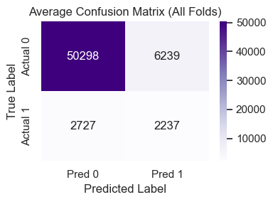

```python
from catboost import Pool

# Use best parameters and threshold from earlier Optuna + threshold tuning
best_params = study_cb.best_params
best_threshold_cb = best_threshold_cb  # defined earlier

# Prepare cross-validation
kf = StratifiedKFold(n_splits=5, shuffle=True, random_state=42)
auc_scores = []
f1_scores = []
conf_matrices = []

for fold, (train_idx, val_idx) in enumerate(kf.split(X_catboost, y)):
    # Create CatBoost Pool objects with categorical features
    train_pool = Pool(data=X_catboost.iloc[train_idx],
                      label=y.iloc[train_idx],
                      cat_features=cat_features)

    val_pool = Pool(data=X_catboost.iloc[val_idx],
                    label=y.iloc[val_idx],
                    cat_features=cat_features)

    # Train model
    model = CatBoostClassifier(**best_params)
    model.fit(train_pool, verbose=0)

    # Predict
    y_probs = model.predict_proba(val_pool)[:, 1]
    y_preds = (y_probs > best_threshold_cb).astype(int)

    # Metrics
    auc_scores.append(roc_auc_score(y.iloc[val_idx], y_probs))
    f1_scores.append(f1_score(y.iloc[val_idx], y_preds))
    conf_matrices.append(confusion_matrix(y.iloc[val_idx], y_preds))

    print(f"\nFold {fold} Confusion Matrix:\n{conf_matrices[-1]}")

# Aggregate results
avg_conf = np.mean(conf_matrices, axis=0).astype(int)
print(f"\nAverage Confusion Matrix Across Folds:")
print(avg_conf)

print(f"\nCross-validated AUC: {np.mean(auc_scores):.4f}")
print(f"Cross-validated F1: {np.mean(f1_scores):.4f}")

# Visualize confusion matrix
plt.figure(figsize=(4, 3))
sns.heatmap(avg_conf, annot=True, fmt="d", cmap="Purples",
            xticklabels=["Pred 0", "Pred 1"],
            yticklabels=["Actual 0", "Actual 1"])
plt.title("Average Confusion Matrix (All Folds)")
plt.xlabel("Predicted Label")
plt.ylabel("True Label")
plt.tight_layout()
plt.show()
```

## 6.6 Final SHAP Analysis (Domain-Grouped)

#### Global SHAP Importance (All Features)

- Bar plot and violin plot summarize which features contributed most across all predictions.